# Trump’s Tweetanalyse

Thomas de Beus

08 January, 2018

[figure not shown]

# 1 Waarom een tweetanalyse?

Een eerste jaar Donald J. Trump in het witte huis. Misschien wel mede mogelijk gemaakt door zijn karakteristieke uitlatingen op Twitter. In de aanloop van de verkiezingen zijn de tweets van de huidige president van de V.S. een krachtig middel gebleken. En nog steeds bereikt hij zijn miljoenen kiezers zonder de traditionele media nodig te hebben. Trump zelf verschijnt dan ook relatief weinig voor de camera, in kranten of andere news sites.

Om beter vat te krijgen op hoe Trump zijn favoriete medium inzet nemen we zijn tweets onder de loep. **Doormiddel van een tekstanalyse hopen we een aantal vragen te beantwoorden**.

Vragen zoals:

- Welke Tweets zijn daadwerkelijk van Trump afkomstig?
- Hoeveel tweets stuurt Trump gemiddeld per dag?
- Wanneer op de dag tweet hij met name? s’Avonds, s’ochtends of s’middags?
- Welke tweets worden het meest geretweet en geliked?
- Welke woorden gebruikt Trump het meest?

# 2 Data verkrijgen

De geïmporteerde dataset is van [Trump Twitter Archive](http://www.trumptwitterarchive.com/archive). Dit is een betere bron dan de Twitter API welke niet altijd alle tweets geeft. Bovendien slaat de Trump Twitter Archive ook de meeste verwijderde tweets op.

Trump Twitter Archive word elk uur geupdate. Als wij de code in onder de R-script op deze pagina ‘runnen’ dan worden alle data tabellen en grafieken als vanzelf geupdate. De twitter dataset bevat de volgende *zeven* variabelen:

- `text`: tekst van de tweets.
- `created_at`: datum en tijd van tweet in “GMT”
- `source`: op welk apparaat of met welke software de tweet is gepost
- `retweet_count`: aantal ‘retweets’
- `favourite_count`: aantal ‘vind-ik-leuks’
- `is_retweet`: of de tweet een retweet is of niet
- `id_str`: uniek karakter van tweet

```r
# Loading the used libraries
library(tidyverse)
library(lubridate)
library(tidytext)
library(DT)
library(scales)
library(hrbrthemes)
library(cowplot)
library(rvest)
library(ggthemes)

# url Trump Twitter Archive
url <- 'http://www.trumptwitterarchive.com/data/realdonaldtrump/%s.json'
# Retrieve all trump's tweets and create dataset with converted `created_at` character dates
original_df <- map(2009:2017, ~sprintf(url, .x)) %>%
  map_df(jsonlite::fromJSON, simplifyDataFrame = TRUE) %>%
  mutate(created_at = parse_date_time(created_at, "a b! d! H!:M!:S! z!* Y!")) %>%
  tbl_df()
# If above doesn't work download data on website then:
# original_df <- read.csv("filename.csv", quote = "", comment = "")
```

## 2.1 Klaarmaken voor analyse: Wanneer zijn de tweets afkomstig van Trump zelf?

Het uiteindelijke doel is om een dataset te maken met unieke Trump tweets. Omdat data scientist David Robinson in zijn analyse, [Text analysis of Trump’s tweets confirms he writes only the (angrier) Android half](http://varianceexplained.org/r/trump-tweets/), er vrijwel zeker van is dat Trump destijds een Android toestel gebruikte [passen anderen machine learning toe](http://didtrumptweetit.com/).

Wij zullen dat in deze analyse overnemen door de computer op tweets te laten filteren waarvan de `text` hashtags (“#”) en/of links (“http”) bevatten. Afbeeldingen worden tegenwoordig niet meer in de text van de tweets meegenomen. Ook nemen we de tweets die vanaf andere toestellen afkomstig zijn niet mee.

Het spreekt voor zich dat we alleen originele tweets meenemen dus geen retweets. Bovendien zullen gelijk al filteren op de tweets die vanaf zijn inauguratie zijn verstuurd (20-101-2017).

```r
# Subset data on high probability that Trump himself is actually tweeting and add
all_trump_tweets <- original_df %>%
  rename(retweets = retweet_count,
         favorites = favorite_count) %>%
  filter(is_retweet != "true",
         source == "Twitter for iPhone" |
         source == "Twitter for Android",
         !grepl("http|#|RT|@realdonaldtrump|@realDonaldTrump", text)) %>%
  rowid_to_column("ID") %>%
  select(ID, text, created_at, retweets, favorites, source)
# Filter out all iPhone tweets before 25-03-2017
all_trump_tweets <- all_trump_tweets %>%
  filter((created_at < "2017-03-15" & source != "Twitter for iPhone") | created_at >= "2017-03-15") %>%
  arrange(desc(created_at))
# Get rid of emoji characters R doesn't like them
all_trump_tweets$text <- gsub("[^\x01-\x7F]", "", all_trump_tweets$text)
# Remove redundant "amp"
all_trump_tweets$text <- gsub("amp", "", all_trump_tweets$text)
# Remove numbers
all_trump_tweets$text <- gsub("[0-9]+", "", all_trump_tweets$text)
# Convert GMT time to Eastern US time want Trump tweet daarvanuit het meest en originele tijden zijn GMT (Greenwich Time)
all_trump_tweets$created_at <- with_tz(all_trump_tweets$created_at, tzone = "US/Eastern")
# Create dataset since inauguration
president_tweets <- all_trump_tweets %>%
  filter(created_at > "2017-01-20")
# Create dataset since inauguration
candidate_tweets <- all_trump_tweets %>%
  filter(created_at > "2015-06-16")
# Html widget interactive table in rmarkdown report with only the four useful columns
datatable(head(president_tweets[,c(2,5,6,1,4)], n = nrow(president_tweets)), options = list(pageLength = 5))
```

[output not shown]

# 3 Data analyseren

```r
# Top 10 retweets
most_rt <- president_tweets %>%
  arrange(desc(retweets))
# Html widget interactive table in rmarkdown report
datatable(head(most_rt[,c(2, 4, 5, 3)], n = nrow(most_rt)), options = list(pageLength = 5))
```

|  | text | retweets | favorites | created_at |
| --- | --- | --- | --- | --- |
| 1 | Despite the constant negative press covfefe | 127507 | 162788 | 2017-05-31T04:06:25Z |
| 2 | I have great confidence in King Salman and the Crown Prince of Saudi Arabia, they know exactly what they are doing.... | 98277 | 120715 | 2017-11-06T23:03:35Z |
| 3 | During my recent trip to the Middle East I stated that there can no longer be funding of Radical Ideology. Leaders pointed to Qatar - look! | 87163 | 79181 | 2017-06-06T12:06:35Z |
| 4 | Who can figure out the true meaning of "covfefe" ??? Enjoy! | 85555 | 209543 | 2017-05-31T10:09:22Z |
| 5 | Peaceful protests are a hallmark of our democracy. Even if I don't always agree, I recognize the rights of people to express their views. | 81527 | 390826 | 2017-01-22T14:23:17Z |
| 6 | Now that the three basketball players are out of China and saved from years in jail, LaVar Ball, the father of LiAngelo, is unaccepting of what I did for his son and that shoplifting is no big deal. I… | 77081 | 275392 | 2017-11-19T17:42:36Z |
| 7 | We must stop being politically correct and get down to the business of security for our people. If we don't get smart it will only get worse | 76260 | 246690 | 2017-06-04T11:19:47Z |
| 8 | My warmest condolences and sympathies to the victims and families of the terrible Las Vegas shooting. God bless you! | 75476 | 317744 | 2017-10-02T11:11:37Z |
| 9 | What an amazing comeback and win by the Patriots. Tom Brady, Bob Kraft and Coach B are total winners. Wow! | 72934 | 267584 | 2017-02-06T03:36:54Z |
| 10 | Subject to the receipt of further information, I will be allowing, as President, the long blocked and classified JFK FILES to be opened. | 70990 | 213796 | 2017-10-21T12:35:05Z |

[output cut: 1305 more lines]

## 3.1 Text analyse per woord

Welke woorden gebruikt Trump het meest in zijn tweets?

### 3.1.1 Vanaf Inauguratie

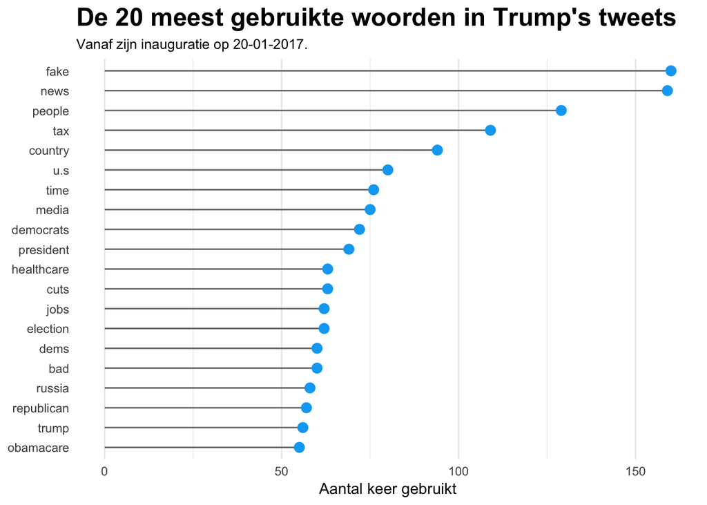

```r
# Create new dataset `tweets_fy_words` (tweets first year words)
tweets_words <- president_tweets %>%
  unnest(text) %>% # Unnest gets rid of lists in text column
  unnest_tokens(word, text)
# Remove stop words and numbers, which aren't useful
tweets_words <- tweets_words %>%
  anti_join(stop_words) # Because in text is 'space' coded as "amp&"

# Sort on most used words
most_used_words <- tweets_words %>%
  count(word, sort = TRUE) %>%
  mutate(times_used = n,
         word = reorder(word, times_used)) %>%
  select(word, times_used)
# Convert type word column to charcter for better handeling
most_used_words$word <- as.character(most_used_words$word)
# Sort on times_used
most_used_words <- most_used_words %>%
  arrange(desc(times_used))
# Plot in bar chart
plot_most_used_words <- most_used_words %>%
  top_n(20) %>%
  ggplot(aes(x = reorder(word, times_used), times_used)) +
    geom_segment(aes(x = reorder(word, times_used), xend = word, y = 0,yend = times_used),
               colour = "#737373") +
  geom_point(colour = "#03A9F4",
             size = 3) +
  coord_flip() +
  theme_minimal() +
  theme(panel.grid.major.y = element_blank(),
        plot.background = element_blank(),
        plot.title = element_text(face = "bold",
                                  size = 18)) +
  labs(title = "De 20 meest gebruikte woorden in Trump's tweets",
       subtitle = "Vanaf zijn inauguratie op 20-01-2017.",
       x = NULL,
       y = "Aantal keer gebruikt")

# Plot
plot_most_used_words
```

```r
# Html widget interactive table in rmarkdown report
datatable(head(most_used_words, n = nrow(most_used_words)), options = list(pageLength = 5))
```

|  | word | times_used |
| --- | --- | --- |
| 1 | fake | 160 |
| 2 | news | 159 |
| 3 | people | 129 |
| 4 | tax | 109 |
| 5 | country | 94 |
| 6 | u.s | 80 |
| 7 | time | 76 |
| 8 | media | 75 |
| 9 | democrats | 72 |
| 10 | president | 69 |

[output cut: 3357 more lines]

## 3.2 Welke woordparen gebruikt Trump het vaakst?

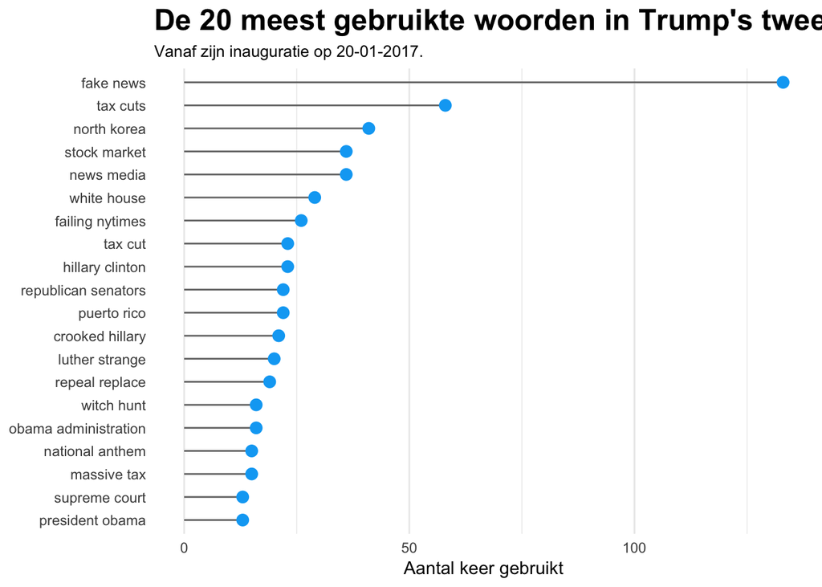

```r
candidate_bigrams <- candidate_tweets %>%
  unnest_tokens(bigram , text, token = "ngrams", n = 2) %>%
  separate(bigram, c("word1", "word2"), sep = " ") %>%
  filter(!word1 %in% stop_words$word) %>%
  filter(!word2 %in% stop_words$word) %>%
  unite(bigram, word1, word2, sep = " ")

president_bigrams <- candidate_bigrams %>%
  filter(created_at > "2017-01-20") %>%
  group_by(bigram) %>%
  mutate(count = n())

head(president_bigrams %>%
  mutate(count = n()) %>%
  distinct(bigram, count) %>%
    arrange(desc(count)),20) %>%
  ggplot(aes(x = reorder(bigram, count), count)) +
    geom_segment(aes(x = reorder(bigram, count), xend = bigram, y = 0,yend = count),
               colour = "#737373") +
  geom_point(colour = "#03A9F4",
             size = 3) +
  coord_flip() +
  theme_minimal() +
  theme(panel.grid.major.y = element_blank(),
        plot.background = element_blank(),
        plot.title = element_text(face = "bold",
                                  size = 18)) +
  labs(title = "De 20 meest gebruikte woorden in Trump's tweets",
       subtitle = "Vanaf zijn inauguratie op 20-01-2017.",
       x = NULL,
       y = "Aantal keer gebruikt")
```

## 3.3 Wanneer op de dag verstuurt Trump zijn tweets?

- Trump vanaf toen hij president was
- Trump vanaf dat hij zich officieel kandidaat stelde
- Trump van vóór zijn kandidaatstelling

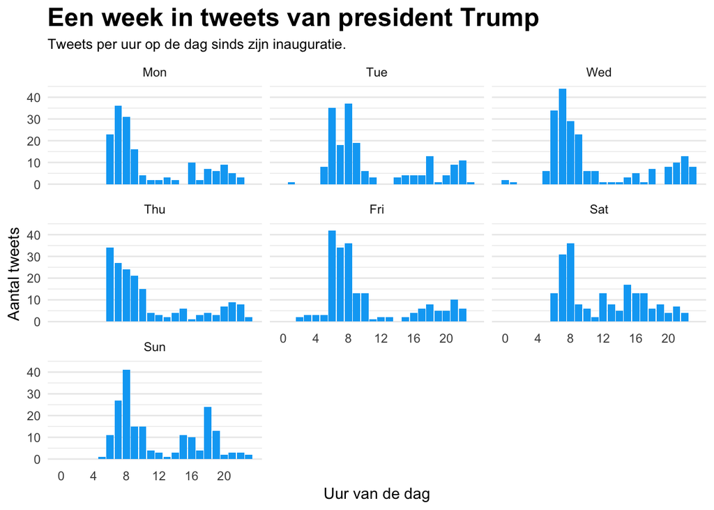

```r
# Create dataframe with weekdays
weekday_tweets <- president_tweets %>%
  mutate(hour_of_day = hour(created_at),
         weekday = strftime(created_at, "%a")) %>%
  group_by(weekday, hour_of_day) %>%
  summarize(count = n()) %>%
  mutate(percentage = count / sum(count))
# Order weekdays on Monday first
weekday_tweets$weekday <- factor(weekday_tweets$weekday, levels = c("Mon",
    "Tue", "Wed", "Thu", "Fri", "Sat", "Sun"))
# Plot distributions
weekday_tweets %>%
  ggplot(aes(hour_of_day, count)) +
  geom_col(fill = "#03A9F4") +
  scale_x_continuous(breaks = seq(0,23,4)) +
  theme_minimal() +
  theme(panel.grid.major.x = element_blank(),
        panel.grid.minor.x = element_blank(),
        plot.title = element_text(face = "bold",
                                  size = 18)) +
  labs(title = "Een week in tweets van president Trump",
       subtitle = "Tweets per uur op de dag sinds zijn inauguratie.",
       x = "Uur van de dag",
       y = "Aantal tweets") +
  facet_wrap(~weekday)
```

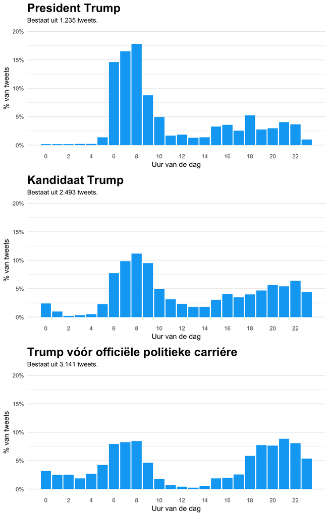

```r
# -------------------President

# Create datframe that groups hours a day and the nr of tweets during his presidency and add percentage column
tweet_time_president <- all_trump_tweets %>%
  mutate(hour_of_day = hour(created_at)) %>%
  filter(created_at > "2017-01-20") %>% # Consists of 1.235 tweets
  group_by(hour_of_day) %>%
  summarize(count = n()) %>%
  mutate(percentage = count / sum(count))
# Plot a bar chart of a day
plot_tweet_time_president <- tweet_time_president %>%
  ggplot(aes(hour_of_day, percentage)) +
  geom_col(fill = "#03A9F4") +
  theme_minimal() +
  scale_y_continuous(labels = percent_format(),
                     limits=c(0,0.2)) +
  scale_x_continuous(breaks = seq(0,23,2)) +
  theme(panel.grid.major.x = element_blank(),
        panel.grid.minor.x = element_blank(),
        plot.title = element_text(face = "bold",
                                  size = 18)) +
  labs(title = "President Trump",
       subtitle = "Bestaat uit 1.235 tweets.",
       x = "Uur van de dag",
       y = "% van tweets")

# -------------------Candidate

# Same calculation than `tweet_time_president` but filterd before inauguration and after announcing official canidatcy
tweet_time_candidate <- all_trump_tweets %>%
  mutate(hour_of_day = hour(created_at)) %>%
  filter(created_at < "2017-01-20" &
           created_at > "2015-06-16") %>% # Consists of 2.493 tweets
  group_by(hour_of_day) %>%
  summarize(count = n()) %>%
  mutate(percentage = count / sum(count))
# Plotting same barchart
plot_tweet_time_candidate <- tweet_time_candidate %>%
  ggplot(aes(hour_of_day, percentage)) +
  geom_col(fill = "#03A9F4") +
  theme_minimal() +
  scale_y_continuous(labels = percent_format(),
                     limits=c(0,0.2)) +
  scale_x_continuous(breaks = seq(0,23,2)) +
  theme(panel.grid.major.x = element_blank(),
        panel.grid.minor.x = element_blank(),
        plot.title = element_text(face = "bold",
                                  size = 18)) +
  labs(title = "Kandidaat Trump",
       subtitle = "Bestaat uit 2.493 tweets.",
       x = "Uur van de dag",
       y = "% van tweets")

# --------------------Before Politics

# Same calculation but filterd before announcing official canidatcy
tweet_time_before_politics <- all_trump_tweets %>%
  mutate(hour_of_day = hour(created_at)) %>%
  filter(created_at < "2015-06-16") %>% # Consists of 3.141 tweets
  group_by(hour_of_day) %>%
  summarize(count = n()) %>%
  mutate(percentage = count / sum(count))
# Plotting same barchart
plot_tweet_time_before_politics <- tweet_time_before_politics %>%
  ggplot(aes(hour_of_day, percentage)) +
  geom_col(fill = "#03A9F4") +
  theme_minimal() +
  scale_y_continuous(labels = percent_format(),
                     limits=c(0,0.2)) +
  scale_x_continuous(breaks = seq(0,23,2)) +
  theme(panel.grid.major.x = element_blank(),
        panel.grid.minor.x = element_blank(),
        plot.title = element_text(face = "bold",
                                  size = 18)) +
  labs(title = "Trump vóór officiële politieke carriére ",
       subtitle = "Bestaat uit 3.141 tweets.",
       x = "Uur van de dag",
       y = "% van tweets")

# Place al three plot's in grid
plot_grid(plot_tweet_time_president, plot_tweet_time_candidate, plot_tweet_time_before_politics, ncol = 1, align = 'v')
```

## 3.4 Wanneer heeft Trump welke woordparen gebruikt

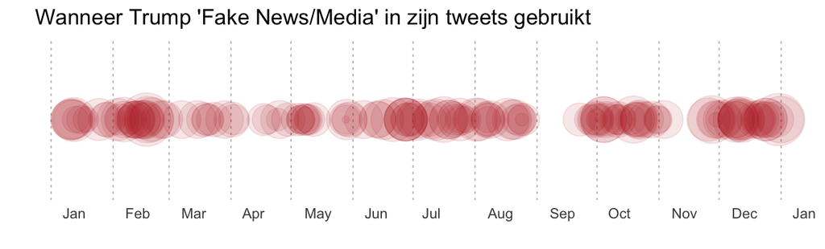

```r
# Bubble time line
bubble_plot_1 <- candidate_bigrams %>%
  filter(created_at > "2017-01-01",
         grepl("fake news|fake media", bigram, ignore.case = TRUE)) %>%
  ggplot(aes(x = created_at, y = 0)) +
  geom_point(aes(size = retweets),
             alpha = 0.1,
             colour = "#B71C1C") +
  scale_size(range = c(0,15)) +
  scale_x_datetime(date_labels = "%b", date_breaks = "1 month") +
  theme_minimal() +
  theme(legend.position = "none",
        plot.background = element_blank(),
        axis.text.y = element_blank(),
        axis.text.x = element_text(hjust = -0.5),
        panel.grid = element_blank(),
        panel.grid.major.x = element_line(colour = "#BDBDBD",
                                          linetype = "dotted")) +
  labs(title = "Wanneer Trump 'Fake News/Media' in zijn tweets gebruikt",
       x = "",
       y = "")

bubble_plot_1
```

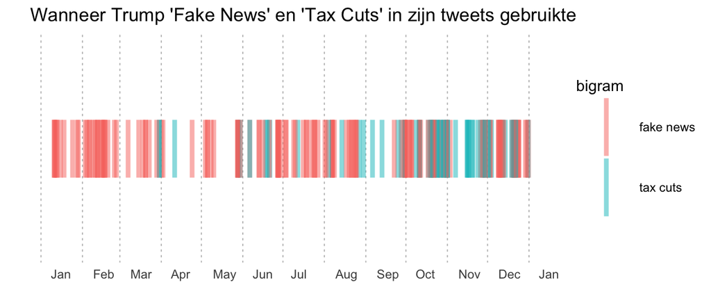

```r
# Barcode with fixed size
barcode_1 <- candidate_bigrams %>%
  filter(created_at > "2017-01-01",
         bigram %in% c("fake news",
                       "tax cuts")) %>%
  ggplot(aes(x = created_at, y = 0, colour = bigram)) +
  geom_point(shape = 124,
             size = 15,
             alpha = 0.5) +
  scale_x_datetime(date_labels = "%b", date_breaks = "1 month") +
  theme_minimal() +
  theme(plot.background = element_blank(),
        axis.text.y = element_blank(),
        axis.text.x = element_text(hjust = -0.5),
        panel.grid = element_blank(),
        panel.grid.major.x = element_line(colour = "#BDBDBD",
                                          linetype = "dotted")) +
  labs(title = "Wanneer Trump 'Fake News' en 'Tax Cuts' in zijn tweets gebruikte",
       x = "",
       y = "")

barcode_1
```

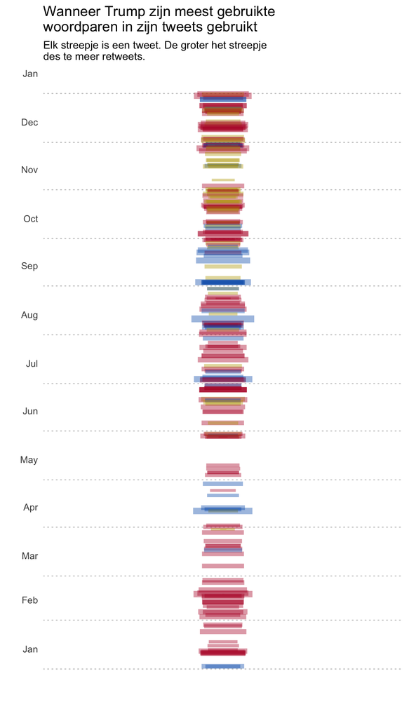

```r
plot_colours3 <- c("#b7002e", "#005cb7", "#baa400")

# Barcode where size is according number of retweets
barcode_2 <- candidate_bigrams %>%
  filter(created_at > "2017-01-01",
         bigram %in% c("fake news",
                       "north korea",
                       "tax cuts")) %>%
  ggplot(aes(x = created_at, y = 0, colour = bigram, size = retweets)) +
  geom_point(shape = 95,
             alpha = 0.4) +
  scale_size(range = c(1, 35)) +
  scale_x_datetime(date_labels = "%b",
                   date_breaks = "1 month") +
  scale_colour_manual(values = plot_colours3) +
  coord_flip() +
  theme_minimal() +
  theme(legend.position = "none",
        plot.background = element_blank(),
        axis.text.x = element_blank(),
        axis.text.y = element_text(vjust = -2.5),
        panel.grid = element_blank(),
        panel.grid.major.y = element_line(colour = "#BDBDBD",
                                          linetype = "dotted")) +
  labs(title = "Wanneer Trump zijn meest gebruikte\nwoordparen in zijn tweets gebruikt",
       subtitle = "Elk streepje is een tweet. De groter het streepje\ndes te meer retweets.",
       x = "",
       y = "")

barcode_2
```

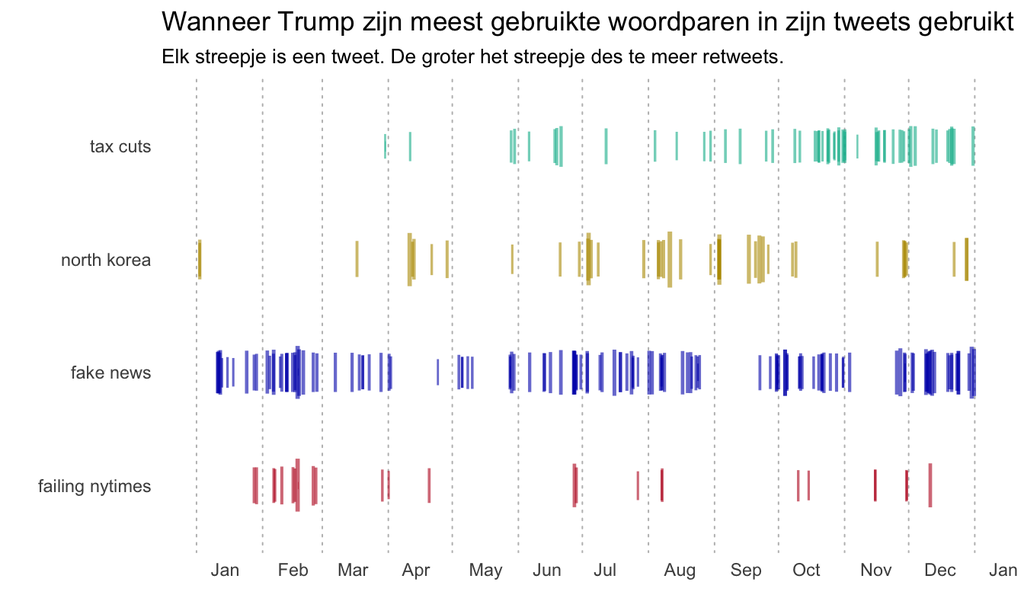

```r
plot_colours4 <- c("#ba001f", "#001fb7", "#b79900", "#00b799")

# Barcode where size is according to number of retweets and multiple words on their own line
barcode_3 <- candidate_bigrams %>%
  filter(created_at > "2017-01-01",
         bigram %in% c("fake news",
                       "north korea",
                       "tax cuts",
                       "failing nytimes")) %>%
  ggplot(aes(x = created_at, y = bigram, colour = bigram, size = retweets)) +
  geom_point(shape = 124,
             alpha = 0.6) +
  scale_size(range = c(1, 10)) +
  scale_x_datetime(date_labels = "%b", date_breaks = "1 month") +
  scale_colour_manual(values = plot_colours4) +
  theme_minimal() +
  theme(legend.position = "none",
        plot.background = element_blank(),
        axis.text.x = element_text(hjust = -0.5),
        panel.grid = element_blank(),
        panel.grid.major.x = element_line(colour = "#BDBDBD",
                                          linetype = "dotted")) +
  labs(title = "Wanneer Trump zijn meest gebruikte woordparen in zijn tweets gebruikt",
       subtitle = "Elk streepje is een tweet. De groter het streepje des te meer retweets.",
       x = "",
       y = "")

barcode_3
```

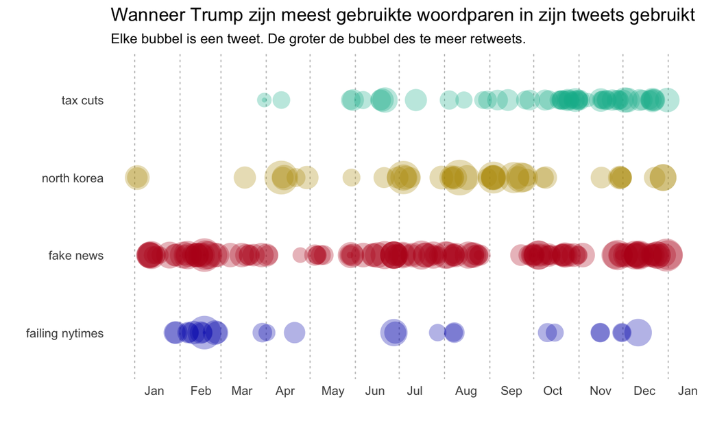

```r
plot_colours4 <- c("#001fb7",  "#ba001f", "#b79900", "#00b799")

# Bubble plot where size is according to number of retweets and multiple words on their own line
candidate_bigrams %>%
  mutate(bigram = as.factor(bigram)) %>%
  filter(created_at > "2017-01-01",
         bigram %in% c("fake news",
                       "north korea",
                       "tax cuts",
                       "failing nytimes")) %>%
  ggplot(aes(x = created_at, y = bigram, fill = bigram, size = retweets)) +
  geom_point(shape = 21,
             alpha = 0.3,
             stroke = F) +
  scale_size(range = c(1, 12)) +
  scale_x_datetime(date_labels = "%b", date_breaks = "1 month") +
  scale_fill_manual(values = plot_colours4) +
  theme_minimal() +
  theme(legend.position = "none",
        plot.background = element_blank(),
        axis.text.x = element_text(hjust = -0.5),
        panel.grid = element_blank(),
        panel.grid.major.x = element_line(colour = "#BDBDBD",
                                          linetype = "dotted")) +
  labs(title = "Wanneer Trump zijn meest gebruikte woordparen in zijn tweets gebruikt",
       subtitle = "Elke bubbel is een tweet. De groter de bubbel des te meer retweets.",
       x = "",
       y = "")
```